# LR RT Analysis

2026-05-19

## 0. Packages

```r
# import packages
library(lme4) # mixed models
library(dplyr) # dataframe manipulation
library(readr) # reading in the data
library(emmeans) # likelihood ratio testing
```

```r
library(purrr) # for map()
library(lattice) # for xyplot()
library(TAF) # setting up output file directory structure during model fitting
library(moments) # skewness for selecting between additive and multiplicative models of response times
library(stringr)


# If you get an error, you likely need to install the packages using the "install.package('insert-package-name-here')" command
```

## Notebook configurable settings

```r
# name the directories to read data from and write output to
input_version <- 9
output_version <- "programming"
program_type <- "long"
```

make an overall output directory (model summaries, stats, etc. will all go here)

```r
outputdir <- sprintf(
  "%s/../candidate-models/regression-models-%s", getwd(), output_version
)
```

```r
mkdir(outputdir)
```

## Loading Data

```r
input_file <- sprintf(
  "%s/../preprocessed-data/full-data-version-%d/programming-full-data.csv",
  getwd(), input_version
)
data <- read.csv(input_file)

# Transforming the session number such that it is treated as a character and not a value
data <- transform(
  data,
  session = as.character(session)
)

# data
```

# Removing irrelevant data from dataframe

```r
# remove rows that have no values
data <- data[data$duration > 0, ]

# Removing the 2 LR problems that were not graded
data <- data[data$accuracy != "", ]


# Removing the one participants that didn't listen to instructions:
participants_to_remove <- c("REDACTED_20")
data <- subset(data, !(participant_id %in% participants_to_remove))
```

Looking at only LR correct responses

```r
data <- data[data$problem_type == "long", ]
data <- data[data$accuracy == "Pass", ]
```

Preview data head

```r
head(data)
```

```
##    problem_order participant_id session problem_set start_time_real
## 8              1     REDACTED_0       1           a        REDACTED
## 15             2     REDACTED_0       1           a        REDACTED
## 18             5     REDACTED_0       1           a        REDACTED
## 29             3     REDACTED_0       2           b        REDACTED
## 34             2     REDACTED_0       2           b        REDACTED
## 49             0     REDACTED_1       1           a        REDACTED
##    start_time_experiment end_time_experiment  duration problem_id problem_type
## 8        00:13:46.316685     00:15:37.253334 110.93665      fr_10         long
## 15       00:23:06.481331     00:25:19.712722 133.23139       fr_8         long
## 18       00:27:29.261913     00:28:01.905248  32.64334       fr_4         long
## 29       00:15:05.630184     00:16:14.998151  69.36797      fr_11         long
## 34       00:20:41.610239     00:21:07.802360  26.19212      fr_13         long
## 49       00:17:35.414141     00:20:27.007106 171.59296      fr_12         long
##    shown
```

[output cut: 76 more lines]

Looking at the average duartion of correctly made LR responses and finding its distribution.

```r
mean_value <- mean((data$duration))

print(mean_value)
```

```
## [1] 83.88911
```

We find the distribution has a skew so we log-transform duration time

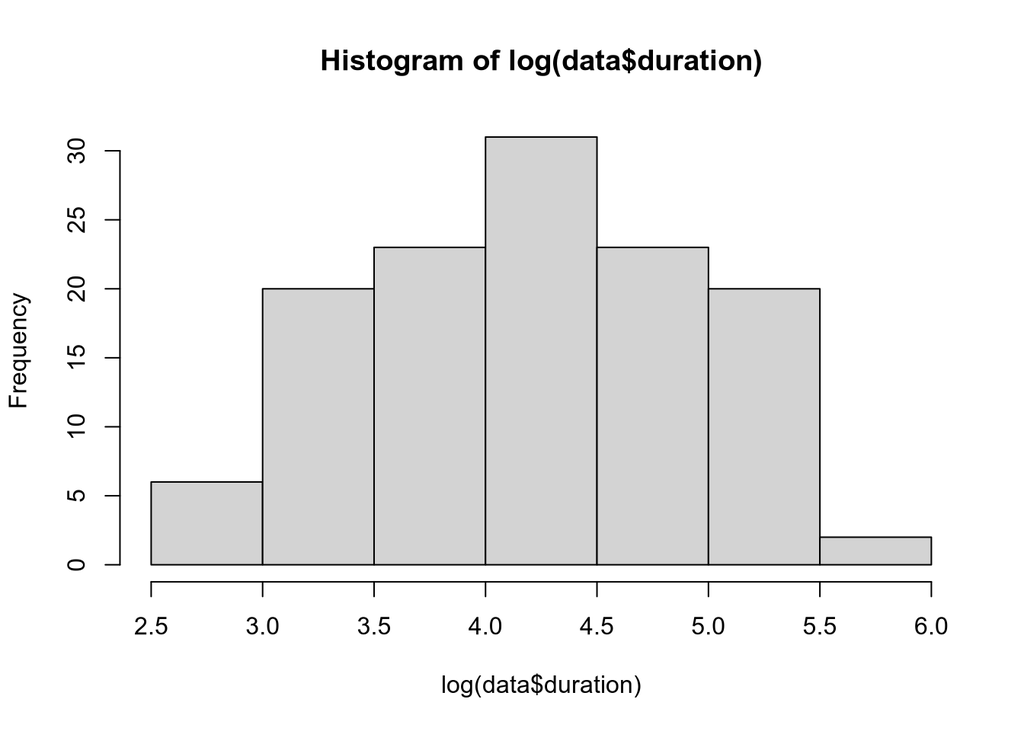

```r
hist(log(data$duration))
```

```r
# Make sure you have n=26 participants - that is because one participant just got all of the LR wrong.

id <- unique(data$participant_id)
id # all unique IDs
```

```
##  [1] "REDACTED_0"  "REDACTED_1"  "REDACTED_10" "REDACTED_11" "REDACTED_12"
##  [6] "REDACTED_13" "REDACTED_14" "REDACTED_15" "REDACTED_16" "REDACTED_17"
## [11] "REDACTED_18" "REDACTED_19" "REDACTED_21" "REDACTED_22" "REDACTED_23"
## [16] "REDACTED_24" "REDACTED_25" "REDACTED_26" "REDACTED_27" "REDACTED_3"
## [21] "REDACTED_4"  "REDACTED_5"  "REDACTED_6"  "REDACTED_7"  "REDACTED_8"
## [26] "REDACTED_9"
```

```r
length(id) # number of participants
```

```
## [1] 26
```

```r
count_table <- table(data$TMS_Type, data$participant_id)

# Print the result
print(count_table)
```

```
##
##      REDACTED_0 REDACTED_1 REDACTED_10 REDACTED_11 REDACTED_12 REDACTED_13
##   CM          2          2           1           3           1           3
##   WM          3          2           1           1           4           2
##
##      REDACTED_14 REDACTED_15 REDACTED_16 REDACTED_17 REDACTED_18 REDACTED_19
##   CM           1           1           3           1           4           1
##   WM           3           2           2           4           3           1
##
##      REDACTED_21 REDACTED_22 REDACTED_23 REDACTED_24 REDACTED_25 REDACTED_26
##   CM           2           3           3           1           1           3
##   WM           3           6           4           3           3           2
##
##      REDACTED_27 REDACTED_3 REDACTED_4 REDACTED_5 REDACTED_6 REDACTED_7
##   CM           2          4          1          4          4          0
##   WM           2          2          3          3          2          1
##
##      REDACTED_8 REDACTED_9
##   CM          3          3
##   WM          1          5
```

```r
fixed_effects <- c(
  # no fixed effects
  "",

  # no interactions
  "TMS_Type",
  "session",
  "coding_section_no",
  "problem_order",
  "problem_set",
  "pain",
  "physical_symptoms",
  "discomfort",
  "sensations",

  "TMS_Type + session",
  "TMS_Type + coding_section_no",
  "TMS_Type + problem_order",
  "TMS_Type + problem_set",
  "session + coding_section_no",
  "session + problem_order",
  "session + problem_set",
  "problem_set + coding_section_no",
  "problem_set + problem_order",
  "coding_section_no + problem_order",

  "TMS_Type + pain",
  "TMS_Type + physical_symptoms",
  "TMS_Type + discomfort",
  "TMS_Type + sensations",
  "session + pain",
  "session + physical_symptoms",
  "session + discomfort",
  "session + sensations",
  "coding_section_no + pain",
  "coding_section_no + physical_symptoms",
  "coding_section_no + discomfort",
  "coding_section_no + sensations",
  "problem_order + pain",
  "problem_order + physical_symptoms",
  "problem_order + discomfort",
  "problem_order + sensations",
  "problem_set + pain",
  "problem_set + physical_symptoms",
  "problem_set + discomfort",
  "problem_set + sensations",

  "TMS_Type + session + coding_section_no + problem_order + problem_set + pain + physical_symptoms + discomfort + sensations",

  # 2-way interactions
  "TMS_Type * session",
  "TMS_Type * coding_section_no",
  "TMS_Type * problem_order",
  "TMS_Type * problem_set",
  "session * coding_section_no",
  "session * problem_order",
  "session * problem_set",
  "problem_set * coding_section_no",
  "problem_set * problem_order",
  "coding_section_no * problem_order",

  "TMS_Type * pain",
  "TMS_Type * physical_symptoms",
  "TMS_Type * discomfort",
  "TMS_Type * sensations",
  "session * pain",
  "session * physical_symptoms",
  "session * discomfort",
  "session * sensations",
  "coding_section_no * pain",
  "coding_section_no * physical_symptoms",
  "coding_section_no * discomfort",
  "coding_section_no * sensations",
  "problem_order * pain",
  "problem_order * physical_symptoms",
  "problem_order * discomfort",
  "problem_order * sensations",
  "problem_set * pain",
  "problem_set * physical_symptoms",
  "problem_set * discomfort",
  "problem_set * sensations",

  # 1- and 2-way interactions
  "TMS_Type * session + problem_set + coding_section_no + problem_order + pain + physical_symptoms + discomfort + sensations",
  "TMS_Type * problem_set + session + coding_section_no + problem_order + pain + physical_symptoms + discomfort + sensations",
  "TMS_Type * coding_section_no + session + problem_set + problem_order + pain + physical_symptoms + discomfort + sensations",
  "TMS_Type * problem_order + session + problem_set + coding_section_no + pain + physical_symptoms + discomfort + sensations",
  "session * problem_set + TMS_Type + coding_section_no + problem_order + pain + physical_symptoms + discomfort + sensations",
  "session * coding_section_no + TMS_Type + problem_set + problem_order + pain + physical_symptoms + discomfort + sensations",
  "session * problem_order + TMS_Type + problem_set + coding_section_no + pain + physical_symptoms + discomfort + sensations",
  "problem_set * coding_section_no + TMS_Type + session + problem_order + pain + physical_symptoms + discomfort + sensations",
  "problem_set * problem_order + TMS_Type + session + coding_section_no + pain + physical_symptoms + discomfort + sensations",
  "coding_section_no * problem_order + TMS_Type + session + problem_set + pain + physical_symptoms + discomfort + sensations",

  "TMS_Type * pain + session + problem_set + coding_section_no + problem_order",
  "TMS_Type * physical_symptoms + session + problem_set + coding_section_no + problem_order",
  "TMS_Type * discomfort + session + problem_set + coding_section_no + problem_order",
  "TMS_Type * sensations + session + problem_set + coding_section_no + problem_order",

  # multiple 2-way interactions
  "TMS_Type * session + problem_set * coding_section_no + problem_order + pain + physical_symptoms + discomfort + sensations",
  "TMS_Type * session + problem_set * problem_order + coding_section_no + pain + physical_symptoms + discomfort + sensations",
  "TMS_Type * session + coding_section_no * problem_order + problem_set + pain + physical_symptoms + discomfort + sensations",
  "TMS_Type * problem_set + session * coding_section_no + problem_order + pain + physical_symptoms + discomfort + sensations",
  "TMS_Type * problem_set + session * problem_order + coding_section_no + pain + physical_symptoms + discomfort + sensations",
  "TMS_Type * problem_set + coding_section_no * problem_order + session + pain + physical_symptoms + discomfort + sensations",
  "TMS_Type * coding_section_no + session * problem_set + problem_order + pain + physical_symptoms + discomfort + sensations",
  "TMS_Type * coding_section_no + session * problem_order + problem_set + pain + physical_symptoms + discomfort + sensations",
  "TMS_Type * coding_section_no + problem_set * problem_order + session + pain + physical_symptoms + discomfort + sensations",
  "TMS_Type * problem_order + session * problem_set + coding_section_no + pain + physical_symptoms + discomfort + sensations",
  "TMS_Type * problem_order + session * coding_section_no + problem_set + pain + physical_symptoms + discomfort + sensations",
  "TMS_Type * problem_order + problem_set * coding_section_no + session + pain + physical_symptoms + discomfort + sensations",
  "session * problem_set + coding_section_no * problem_order + TMS_Type + pain + physical_symptoms + discomfort + sensations",
  "session * coding_section_no + problem_set * problem_order + TMS_Type + pain + physical_symptoms + discomfort + sensations",
  "session * problem_order + problem_set * coding_section_no + TMS_Type + pain + physical_symptoms + discomfort + sensations",

  # 3-way interactions
  "TMS_Type * session * problem_set + coding_section_no + problem_order + pain + physical_symptoms + discomfort + sensations",
  "TMS_Type * session * coding_section_no + problem_set + problem_order + pain + physical_symptoms + discomfort + sensations",
  "TMS_Type * session * problem_order + problem_set + coding_section_no + pain + physical_symptoms + discomfort + sensations",
  "TMS_Type * problem_set * coding_section_no + problem_order + session + pain + physical_symptoms + discomfort + sensations",
  "TMS_Type * problem_set * problem_order + coding_section_no + session + pain + physical_symptoms + discomfort + sensations",
  "TMS_Type * coding_section_no * problem_order + session + problem_set + pain + physical_symptoms + discomfort + sensations",
  "session * problem_set * coding_section_no + problem_order + TMS_Type + pain + physical_symptoms + discomfort + sensations",
  "session * problem_set * problem_order + coding_section_no + TMS_Type + pain + physical_symptoms + discomfort + sensations",
  "session * coding_section_no * problem_order + TMS_Type + problem_set + pain + physical_symptoms + discomfort + sensations",
  "problem_set * coding_section_no * problem_order + TMS_Type + session + pain + physical_symptoms + discomfort + sensations"
)
```

```r
random_effects <- c(
  "participant_id",
  "problem_id",
  "participant_id:TMS_Type",
  "problem_id:TMS_Type"
)
```

```r
random_effects <- map(random_effects, function(s) sprintf("(1|%s)", s))

random_exprs <- c()
N_random <- length(random_effects)
for (k in 1:N_random) {
  iii <- combn(1:N_random, k, simplify = FALSE)
  for (ii in iii) {
    expr <- paste(random_effects[ii], collapse = " + ")
    random_exprs <- append(random_exprs, expr)
  }
}
```

Now, we combine the response variable, fixed effects, and random effects together to generate our candidate model structures.

```r
loglinear_formulae <- c()
for (fe in fixed_effects) {
  for (re in random_exprs) {
    f <- ""
    if (fe == "") {
      f <- sprintf("log(duration) ~ %s", re)
    } else {
      f <- sprintf("log(duration) ~ %s + %s", fe, re)
    }
    loglinear_formulae <- append(loglinear_formulae, f)
  }
}

print(length(loglinear_formulae))
```

```
## [1] 1650
```

Filter out invalid model specifications

```r
# generate all the boolean index vectors

# formulas with TMS fixed effect
has_TMS <- grepl("TMS_Type ", loglinear_formulae, fixed = TRUE)

# formulas with participant random effect
has_participant <- grepl("(1|participant_id)", loglinear_formulae, fixed = TRUE)

# formulas with problem random effect
has_problem <- grepl("(1|problem_id)", loglinear_formulae, fixed = TRUE)

# formulas with TMS x participant random effect
has_TMS_participant <- grepl(
  "(1|participant_id:TMS_Type)", loglinear_formulae, fixed = TRUE
)

# formulas with TMS x problem random effect
has_TMS_problem <- grepl(
  "(1|problem_id:TMS_Type)", loglinear_formulae, fixed = TRUE
)

# remove them

invalid <- (has_TMS_participant & (!has_TMS | !has_participant)) | (has_TMS_problem & (!has_TMS | !has_problem))

invalid_loglinear_formulae <- loglinear_formulae[invalid]
loglinear_formulae <- loglinear_formulae[!invalid]

print(length(loglinear_formulae))
```

```
## [1] 615
```

### Model fitting (~2 minutes)

Here, we fit all the models. Of note, we use MLE rather than REML for compatibility with the AIC model selection strategy.

We also store BIC (an alternative model selection criterion) in addition to AIC here. The two have different theoretical properties, both of which may be useful. Both describe the log likelihood of a fitted model, with a penalty for model complexity. The penalty in BIC is higher than that for AIC, so optimal-BIC models tend to be smaller (with fewer parameters) than optimal-AIC models. We have done our analysis relying on AIC, but we provide BIC-based model selection here in case the reader is interested.

```r
if (TRUE) {
  # make an output directory for the output of all the candidate linear models
  logtime_outputdir <- sprintf("%s/LR_v9-2_log_time_model_summaries", outputdir)
  mkdir(logtime_outputdir)

  # make an output file for the AIC and BIC of each model
  metricsfile <- sprintf("%s/metrics.csv", logtime_outputdir)
  file.create(metricsfile)

  sink(
    file = metricsfile,
    append = FALSE,
    type = "output",
    split = FALSE
  )

  cat("formula,AIC,BIC\n")

  sink()

  for (f in loglinear_formulae) {
    # make an output directory for the output of this specific candidate model
    f_outputdir <- sprintf(
      "%s/%s", logtime_outputdir, gsub(" ", "", f, fixed = TRUE)
    )
    mkdir(f_outputdir)

    # make the individual output file
    summaryfile <- sprintf("%s/summary.txt", f_outputdir)

    file.create(summaryfile)

    # print a delimiter for console output
    cat(sprintf("\n---------------------------------------------\n%s\n", f))

    # fit the model
    m <- lmer(f, data = data, REML = FALSE)

    # send the model summary to the summary file
    sink(
      file = summaryfile,
      append = FALSE,
      type = "output",
      split = FALSE
    )

    print(summary(m))

    sink()

    # send the AIC and BIC to the metrics file
    metrics <- sprintf("%s,%f,%f\n", f, AIC(m), BIC(m))

    sink(
      file = metricsfile,
      append = TRUE,
      type = "output",
      split = FALSE
    )

    cat(metrics)

    sink()
  }
}
```

```
##
## ---------------------------------------------
## log(duration) ~ (1|participant_id)
##
## ---------------------------------------------
## log(duration) ~ (1|problem_id)
##
## ---------------------------------------------
## log(duration) ~ (1|participant_id) + (1|problem_id)
##
## ---------------------------------------------
## log(duration) ~ TMS_Type + (1|participant_id)
##
## ---------------------------------------------
## log(duration) ~ TMS_Type + (1|problem_id)
##
## ---------------------------------------------
## log(duration) ~ TMS_Type + (1|participant_id) + (1|problem_id)
##
## ---------------------------------------------
## log(duration) ~ TMS_Type + (1|participant_id) + (1|participant_id:TMS_Type)
```

```
## boundary (singular) fit: see help('isSingular')
```

```
##
## ---------------------------------------------
## log(duration) ~ TMS_Type + (1|problem_id) + (1|problem_id:TMS_Type)
```

```
## boundary (singular) fit: see help('isSingular')
```

```
##
## ---------------------------------------------
## log(duration) ~ TMS_Type + (1|participant_id) + (1|problem_id) + (1|participant_id:TMS_Type)
```

```
## boundary (singular) fit: see help('isSingular')
```

```
##
## ---------------------------------------------
## log(duration) ~ TMS_Type + (1|participant_id) + (1|problem_id) + (1|problem_id:TMS_Type)
```

```
## boundary (singular) fit: see help('isSingular')
```

```
##
## ---------------------------------------------
## log(duration) ~ TMS_Type + (1|participant_id) + (1|problem_id) + (1|participant_id:TMS_Type) + (1|problem_id:TMS_Type)
```

```
## boundary (singular) fit: see help('isSingular')
```

```
##
## ---------------------------------------------
## log(duration) ~ session + (1|participant_id)
##
## ---------------------------------------------
## log(duration) ~ session + (1|problem_id)
##
## ---------------------------------------------
## log(duration) ~ session + (1|participant_id) + (1|problem_id)
##
## ---------------------------------------------
## log(duration) ~ coding_section_no + (1|participant_id)
##
## ---------------------------------------------
## log(duration) ~ coding_section_no + (1|problem_id)
##
## ---------------------------------------------
## log(duration) ~ coding_section_no + (1|participant_id) + (1|problem_id)
##
## ---------------------------------------------
## log(duration) ~ problem_order + (1|participant_id)
##
## ---------------------------------------------
## log(duration) ~ problem_order + (1|problem_id)
##
## ---------------------------------------------
## log(duration) ~ problem_order + (1|participant_id) + (1|problem_id)
##
## ---------------------------------------------
## log(duration) ~ problem_set + (1|participant_id)
##
## ---------------------------------------------
## log(duration) ~ problem_set + (1|problem_id)
##
## ---------------------------------------------
## log(duration) ~ problem_set + (1|participant_id) + (1|problem_id)
##
## ---------------------------------------------
## log(duration) ~ pain + (1|participant_id)
##
```

[output cut: 29 more lines]

```
##
## ---------------------------------------------
## log(duration) ~ sensations + (1|participant_id) + (1|problem_id)
##
## ---------------------------------------------
## log(duration) ~ TMS_Type + session + (1|participant_id)
##
## ---------------------------------------------
## log(duration) ~ TMS_Type + session + (1|problem_id)
##
## ---------------------------------------------
## log(duration) ~ TMS_Type + session + (1|participant_id) + (1|problem_id)
##
## ---------------------------------------------
## log(duration) ~ TMS_Type + session + (1|participant_id) + (1|participant_id:TMS_Type)
```

```
## boundary (singular) fit: see help('isSingular')
```

```
##
## ---------------------------------------------
## log(duration) ~ TMS_Type + session + (1|problem_id) + (1|problem_id:TMS_Type)
```

```
## boundary (singular) fit: see help('isSingular')
```

```
##
## ---------------------------------------------
## log(duration) ~ TMS_Type + session + (1|participant_id) + (1|problem_id) + (1|participant_id:TMS_Type)
```

```
## boundary (singular) fit: see help('isSingular')
```

```
##
## ---------------------------------------------
## log(duration) ~ TMS_Type + session + (1|participant_id) + (1|problem_id) + (1|problem_id:TMS_Type)
```

```
## boundary (singular) fit: see help('isSingular')
```

```
##
## ---------------------------------------------
## log(duration) ~ TMS_Type + session + (1|participant_id) + (1|problem_id) + (1|participant_id:TMS_Type) + (1|problem_id:TMS_Type)
```

```
## boundary (singular) fit: see help('isSingular')
```

```
##
## ---------------------------------------------
## log(duration) ~ TMS_Type + coding_section_no + (1|participant_id)
##
## ---------------------------------------------
## log(duration) ~ TMS_Type + coding_section_no + (1|problem_id)
##
## ---------------------------------------------
## log(duration) ~ TMS_Type + coding_section_no + (1|participant_id) + (1|problem_id)
##
## ---------------------------------------------
## log(duration) ~ TMS_Type + coding_section_no + (1|participant_id) + (1|participant_id:TMS_Type)
```

```
## boundary (singular) fit: see help('isSingular')
```

```
##
## ---------------------------------------------
## log(duration) ~ TMS_Type + coding_section_no + (1|problem_id) + (1|problem_id:TMS_Type)
```

```
## boundary (singular) fit: see help('isSingular')
```

```
##
## ---------------------------------------------
## log(duration) ~ TMS_Type + coding_section_no + (1|participant_id) + (1|problem_id) + (1|participant_id:TMS_Type)
##
## ---------------------------------------------
## log(duration) ~ TMS_Type + coding_section_no + (1|participant_id) + (1|problem_id) + (1|problem_id:TMS_Type)
```

```
## boundary (singular) fit: see help('isSingular')
```

```
##
## ---------------------------------------------
## log(duration) ~ TMS_Type + coding_section_no + (1|participant_id) + (1|problem_id) + (1|participant_id:TMS_Type) + (1|problem_id:TMS_Type)
```

```
## boundary (singular) fit: see help('isSingular')
```

```
##
## ---------------------------------------------
## log(duration) ~ TMS_Type + problem_order + (1|participant_id)
##
## ---------------------------------------------
## log(duration) ~ TMS_Type + problem_order + (1|problem_id)
##
## ---------------------------------------------
## log(duration) ~ TMS_Type + problem_order + (1|participant_id) + (1|problem_id)
##
## ---------------------------------------------
## log(duration) ~ TMS_Type + problem_order + (1|participant_id) + (1|participant_id:TMS_Type)
```

```
## boundary (singular) fit: see help('isSingular')
```

```
##
## ---------------------------------------------
## log(duration) ~ TMS_Type + problem_order + (1|problem_id) + (1|problem_id:TMS_Type)
```

```
## boundary (singular) fit: see help('isSingular')
```

```
##
## ---------------------------------------------
## log(duration) ~ TMS_Type + problem_order + (1|participant_id) + (1|problem_id) + (1|participant_id:TMS_Type)
```

```
## boundary (singular) fit: see help('isSingular')
```

```
##
## ---------------------------------------------
## log(duration) ~ TMS_Type + problem_order + (1|participant_id) + (1|problem_id) + (1|problem_id:TMS_Type)
```

```
## boundary (singular) fit: see help('isSingular')
```

```
##
## ---------------------------------------------
## log(duration) ~ TMS_Type + problem_order + (1|participant_id) + (1|problem_id) + (1|participant_id:TMS_Type) + (1|problem_id:TMS_Type)
```

```
## boundary (singular) fit: see help('isSingular')
```

```
##
## ---------------------------------------------
## log(duration) ~ TMS_Type + problem_set + (1|participant_id)
##
## ---------------------------------------------
## log(duration) ~ TMS_Type + problem_set + (1|problem_id)
##
## ---------------------------------------------
## log(duration) ~ TMS_Type + problem_set + (1|participant_id) + (1|problem_id)
##
## ---------------------------------------------
## log(duration) ~ TMS_Type + problem_set + (1|participant_id) + (1|participant_id:TMS_Type)
```

```
## boundary (singular) fit: see help('isSingular')
```

```
##
## ---------------------------------------------
## log(duration) ~ TMS_Type + problem_set + (1|problem_id) + (1|problem_id:TMS_Type)
```

```
## boundary (singular) fit: see help('isSingular')
```

```
##
## ---------------------------------------------
## log(duration) ~ TMS_Type + problem_set + (1|participant_id) + (1|problem_id) + (1|participant_id:TMS_Type)
```

```
## boundary (singular) fit: see help('isSingular')
```

```
##
## ---------------------------------------------
## log(duration) ~ TMS_Type + problem_set + (1|participant_id) + (1|problem_id) + (1|problem_id:TMS_Type)
```

```
## boundary (singular) fit: see help('isSingular')
```

```
##
## ---------------------------------------------
## log(duration) ~ TMS_Type + problem_set + (1|participant_id) + (1|problem_id) + (1|participant_id:TMS_Type) + (1|problem_id:TMS_Type)
```

```
## boundary (singular) fit: see help('isSingular')
```

```
##
## ---------------------------------------------
## log(duration) ~ session + coding_section_no + (1|participant_id)
##
## ---------------------------------------------
## log(duration) ~ session + coding_section_no + (1|problem_id)
##
## ---------------------------------------------
## log(duration) ~ session + coding_section_no + (1|participant_id) + (1|problem_id)
##
## ---------------------------------------------
## log(duration) ~ session + problem_order + (1|participant_id)
##
## ---------------------------------------------
## log(duration) ~ session + problem_order + (1|problem_id)
##
## ---------------------------------------------
## log(duration) ~ session + problem_order + (1|participant_id) + (1|problem_id)
##
## ---------------------------------------------
## log(duration) ~ session + problem_set + (1|participant_id)
##
## ---------------------------------------------
## log(duration) ~ session + problem_set + (1|problem_id)
##
## ---------------------------------------------
## log(duration) ~ session + problem_set + (1|participant_id) + (1|problem_id)
##
## ---------------------------------------------
## log(duration) ~ problem_set + coding_section_no + (1|participant_id)
##
## ---------------------------------------------
## log(duration) ~ problem_set + coding_section_no + (1|problem_id)
##
## ---------------------------------------------
## log(duration) ~ problem_set + coding_section_no + (1|participant_id) + (1|problem_id)
##
## ---------------------------------------------
## log(duration) ~ problem_set + problem_order + (1|participant_id)
##
```

[output cut: 11 more lines]

```
##
## ---------------------------------------------
## log(duration) ~ coding_section_no + problem_order + (1|participant_id) + (1|problem_id)
##
## ---------------------------------------------
## log(duration) ~ TMS_Type + pain + (1|participant_id)
##
## ---------------------------------------------
## log(duration) ~ TMS_Type + pain + (1|problem_id)
##
## ---------------------------------------------
## log(duration) ~ TMS_Type + pain + (1|participant_id) + (1|problem_id)
##
## ---------------------------------------------
## log(duration) ~ TMS_Type + pain + (1|participant_id) + (1|participant_id:TMS_Type)
```

```
## boundary (singular) fit: see help('isSingular')
```

```
##
## ---------------------------------------------
## log(duration) ~ TMS_Type + pain + (1|problem_id) + (1|problem_id:TMS_Type)
```

```
## boundary (singular) fit: see help('isSingular')
```

```
##
## ---------------------------------------------
## log(duration) ~ TMS_Type + pain + (1|participant_id) + (1|problem_id) + (1|participant_id:TMS_Type)
```

```
## boundary (singular) fit: see help('isSingular')
```

```
##
## ---------------------------------------------
## log(duration) ~ TMS_Type + pain + (1|participant_id) + (1|problem_id) + (1|problem_id:TMS_Type)
```

```
## boundary (singular) fit: see help('isSingular')
```

```
##
## ---------------------------------------------
## log(duration) ~ TMS_Type + pain + (1|participant_id) + (1|problem_id) + (1|participant_id:TMS_Type) + (1|problem_id:TMS_Type)
```

```
## boundary (singular) fit: see help('isSingular')
```

```
##
## ---------------------------------------------
## log(duration) ~ TMS_Type + physical_symptoms + (1|participant_id)
##
## ---------------------------------------------
## log(duration) ~ TMS_Type + physical_symptoms + (1|problem_id)
##
## ---------------------------------------------
## log(duration) ~ TMS_Type + physical_symptoms + (1|participant_id) + (1|problem_id)
##
## ---------------------------------------------
## log(duration) ~ TMS_Type + physical_symptoms + (1|participant_id) + (1|participant_id:TMS_Type)
```

```
## boundary (singular) fit: see help('isSingular')
```

```
##
## ---------------------------------------------
## log(duration) ~ TMS_Type + physical_symptoms + (1|problem_id) + (1|problem_id:TMS_Type)
```

```
## boundary (singular) fit: see help('isSingular')
```

```
##
## ---------------------------------------------
## log(duration) ~ TMS_Type + physical_symptoms + (1|participant_id) + (1|problem_id) + (1|participant_id:TMS_Type)
```

```
## boundary (singular) fit: see help('isSingular')
```

```
##
## ---------------------------------------------
## log(duration) ~ TMS_Type + physical_symptoms + (1|participant_id) + (1|problem_id) + (1|problem_id:TMS_Type)
```

```
## boundary (singular) fit: see help('isSingular')
```

```
##
## ---------------------------------------------
## log(duration) ~ TMS_Type + physical_symptoms + (1|participant_id) + (1|problem_id) + (1|participant_id:TMS_Type) + (1|problem_id:TMS_Type)
```

```
## boundary (singular) fit: see help('isSingular')
```

```
##
## ---------------------------------------------
## log(duration) ~ TMS_Type + discomfort + (1|participant_id)
##
## ---------------------------------------------
## log(duration) ~ TMS_Type + discomfort + (1|problem_id)
##
## ---------------------------------------------
## log(duration) ~ TMS_Type + discomfort + (1|participant_id) + (1|problem_id)
##
## ---------------------------------------------
## log(duration) ~ TMS_Type + discomfort + (1|participant_id) + (1|participant_id:TMS_Type)
```

```
## boundary (singular) fit: see help('isSingular')
```

```
##
## ---------------------------------------------
## log(duration) ~ TMS_Type + discomfort + (1|problem_id) + (1|problem_id:TMS_Type)
```

```
## boundary (singular) fit: see help('isSingular')
```

```
##
## ---------------------------------------------
## log(duration) ~ TMS_Type + discomfort + (1|participant_id) + (1|problem_id) + (1|participant_id:TMS_Type)
```

```
## boundary (singular) fit: see help('isSingular')
```

```
##
## ---------------------------------------------
## log(duration) ~ TMS_Type + discomfort + (1|participant_id) + (1|problem_id) + (1|problem_id:TMS_Type)
```

```
## boundary (singular) fit: see help('isSingular')
```

```
##
## ---------------------------------------------
## log(duration) ~ TMS_Type + discomfort + (1|participant_id) + (1|problem_id) + (1|participant_id:TMS_Type) + (1|problem_id:TMS_Type)
```

```
## boundary (singular) fit: see help('isSingular')
```

```
##
## ---------------------------------------------
## log(duration) ~ TMS_Type + sensations + (1|participant_id)
##
## ---------------------------------------------
## log(duration) ~ TMS_Type + sensations + (1|problem_id)
##
## ---------------------------------------------
## log(duration) ~ TMS_Type + sensations + (1|participant_id) + (1|problem_id)
##
## ---------------------------------------------
## log(duration) ~ TMS_Type + sensations + (1|participant_id) + (1|participant_id:TMS_Type)
```

```
## boundary (singular) fit: see help('isSingular')
```

```
##
## ---------------------------------------------
## log(duration) ~ TMS_Type + sensations + (1|problem_id) + (1|problem_id:TMS_Type)
```

```
## boundary (singular) fit: see help('isSingular')
```

```
##
## ---------------------------------------------
## log(duration) ~ TMS_Type + sensations + (1|participant_id) + (1|problem_id) + (1|participant_id:TMS_Type)
```

```
## boundary (singular) fit: see help('isSingular')
```

```
##
## ---------------------------------------------
## log(duration) ~ TMS_Type + sensations + (1|participant_id) + (1|problem_id) + (1|problem_id:TMS_Type)
```

```
## boundary (singular) fit: see help('isSingular')
```

```
##
## ---------------------------------------------
## log(duration) ~ TMS_Type + sensations + (1|participant_id) + (1|problem_id) + (1|participant_id:TMS_Type) + (1|problem_id:TMS_Type)
```

```
## boundary (singular) fit: see help('isSingular')
```

```
##
## ---------------------------------------------
## log(duration) ~ session + pain + (1|participant_id)
##
## ---------------------------------------------
## log(duration) ~ session + pain + (1|problem_id)
##
## ---------------------------------------------
## log(duration) ~ session + pain + (1|participant_id) + (1|problem_id)
##
## ---------------------------------------------
## log(duration) ~ session + physical_symptoms + (1|participant_id)
##
## ---------------------------------------------
## log(duration) ~ session + physical_symptoms + (1|problem_id)
##
## ---------------------------------------------
## log(duration) ~ session + physical_symptoms + (1|participant_id) + (1|problem_id)
##
## ---------------------------------------------
## log(duration) ~ session + discomfort + (1|participant_id)
##
## ---------------------------------------------
## log(duration) ~ session + discomfort + (1|problem_id)
##
## ---------------------------------------------
## log(duration) ~ session + discomfort + (1|participant_id) + (1|problem_id)
##
## ---------------------------------------------
## log(duration) ~ session + sensations + (1|participant_id)
##
## ---------------------------------------------
## log(duration) ~ session + sensations + (1|problem_id)
##
## ---------------------------------------------
## log(duration) ~ session + sensations + (1|participant_id) + (1|problem_id)
##
## ---------------------------------------------
## log(duration) ~ coding_section_no + pain + (1|participant_id)
##
```

[output cut: 101 more lines]

```
##
## ---------------------------------------------
## log(duration) ~ problem_set + sensations + (1|participant_id) + (1|problem_id)
##
## ---------------------------------------------
## log(duration) ~ TMS_Type + session + coding_section_no + problem_order + problem_set + pain + physical_symptoms + discomfort + sensations + (1|participant_id)
##
## ---------------------------------------------
## log(duration) ~ TMS_Type + session + coding_section_no + problem_order + problem_set + pain + physical_symptoms + discomfort + sensations + (1|problem_id)
##
## ---------------------------------------------
## log(duration) ~ TMS_Type + session + coding_section_no + problem_order + problem_set + pain + physical_symptoms + discomfort + sensations + (1|participant_id) + (1|problem_id)
##
## ---------------------------------------------
## log(duration) ~ TMS_Type + session + coding_section_no + problem_order + problem_set + pain + physical_symptoms + discomfort + sensations + (1|participant_id) + (1|participant_id:TMS_Type)
```

```
## boundary (singular) fit: see help('isSingular')
```

```
##
## ---------------------------------------------
## log(duration) ~ TMS_Type + session + coding_section_no + problem_order + problem_set + pain + physical_symptoms + discomfort + sensations + (1|problem_id) + (1|problem_id:TMS_Type)
```

```
## boundary (singular) fit: see help('isSingular')
```

```
##
## ---------------------------------------------
## log(duration) ~ TMS_Type + session + coding_section_no + problem_order + problem_set + pain + physical_symptoms + discomfort + sensations + (1|participant_id) + (1|problem_id) + (1|participant_id:TMS_Type)
```

```
## boundary (singular) fit: see help('isSingular')
```

```
##
## ---------------------------------------------
## log(duration) ~ TMS_Type + session + coding_section_no + problem_order + problem_set + pain + physical_symptoms + discomfort + sensations + (1|participant_id) + (1|problem_id) + (1|problem_id:TMS_Type)
```

```
## boundary (singular) fit: see help('isSingular')
```

```
##
## ---------------------------------------------
## log(duration) ~ TMS_Type + session + coding_section_no + problem_order + problem_set + pain + physical_symptoms + discomfort + sensations + (1|participant_id) + (1|problem_id) + (1|participant_id:TMS_Type) + (1|problem_id:TMS_Type)
```

```
## boundary (singular) fit: see help('isSingular')
```

```
##
## ---------------------------------------------
## log(duration) ~ TMS_Type * session + (1|participant_id)
##
## ---------------------------------------------
## log(duration) ~ TMS_Type * session + (1|problem_id)
##
## ---------------------------------------------
## log(duration) ~ TMS_Type * session + (1|participant_id) + (1|problem_id)
##
## ---------------------------------------------
## log(duration) ~ TMS_Type * session + (1|participant_id) + (1|participant_id:TMS_Type)
```

```
## boundary (singular) fit: see help('isSingular')
```

```
##
## ---------------------------------------------
## log(duration) ~ TMS_Type * session + (1|problem_id) + (1|problem_id:TMS_Type)
```

```
## boundary (singular) fit: see help('isSingular')
```

```
##
## ---------------------------------------------
## log(duration) ~ TMS_Type * session + (1|participant_id) + (1|problem_id) + (1|participant_id:TMS_Type)
```

```
## boundary (singular) fit: see help('isSingular')
```

```
##
## ---------------------------------------------
## log(duration) ~ TMS_Type * session + (1|participant_id) + (1|problem_id) + (1|problem_id:TMS_Type)
```

```
## boundary (singular) fit: see help('isSingular')
```

```
##
## ---------------------------------------------
## log(duration) ~ TMS_Type * session + (1|participant_id) + (1|problem_id) + (1|participant_id:TMS_Type) + (1|problem_id:TMS_Type)
```

```
## boundary (singular) fit: see help('isSingular')
```

```
##
## ---------------------------------------------
## log(duration) ~ TMS_Type * coding_section_no + (1|participant_id)
##
## ---------------------------------------------
## log(duration) ~ TMS_Type * coding_section_no + (1|problem_id)
##
## ---------------------------------------------
## log(duration) ~ TMS_Type * coding_section_no + (1|participant_id) + (1|problem_id)
##
## ---------------------------------------------
## log(duration) ~ TMS_Type * coding_section_no + (1|participant_id) + (1|participant_id:TMS_Type)
```

```
## boundary (singular) fit: see help('isSingular')
```

```
##
## ---------------------------------------------
## log(duration) ~ TMS_Type * coding_section_no + (1|problem_id) + (1|problem_id:TMS_Type)
```

```
## boundary (singular) fit: see help('isSingular')
```

```
##
## ---------------------------------------------
## log(duration) ~ TMS_Type * coding_section_no + (1|participant_id) + (1|problem_id) + (1|participant_id:TMS_Type)
##
## ---------------------------------------------
## log(duration) ~ TMS_Type * coding_section_no + (1|participant_id) + (1|problem_id) + (1|problem_id:TMS_Type)
```

```
## boundary (singular) fit: see help('isSingular')
```

```
##
## ---------------------------------------------
## log(duration) ~ TMS_Type * coding_section_no + (1|participant_id) + (1|problem_id) + (1|participant_id:TMS_Type) + (1|problem_id:TMS_Type)
```

```
## boundary (singular) fit: see help('isSingular')
```

```
##
## ---------------------------------------------
## log(duration) ~ TMS_Type * problem_order + (1|participant_id)
##
## ---------------------------------------------
## log(duration) ~ TMS_Type * problem_order + (1|problem_id)
##
## ---------------------------------------------
## log(duration) ~ TMS_Type * problem_order + (1|participant_id) + (1|problem_id)
##
## ---------------------------------------------
## log(duration) ~ TMS_Type * problem_order + (1|participant_id) + (1|participant_id:TMS_Type)
```

```
## boundary (singular) fit: see help('isSingular')
```

```
##
## ---------------------------------------------
## log(duration) ~ TMS_Type * problem_order + (1|problem_id) + (1|problem_id:TMS_Type)
```

```
## boundary (singular) fit: see help('isSingular')
```

```
##
## ---------------------------------------------
## log(duration) ~ TMS_Type * problem_order + (1|participant_id) + (1|problem_id) + (1|participant_id:TMS_Type)
```

```
## boundary (singular) fit: see help('isSingular')
```

```
##
## ---------------------------------------------
## log(duration) ~ TMS_Type * problem_order + (1|participant_id) + (1|problem_id) + (1|problem_id:TMS_Type)
```

```
## boundary (singular) fit: see help('isSingular')
```

```
##
## ---------------------------------------------
## log(duration) ~ TMS_Type * problem_order + (1|participant_id) + (1|problem_id) + (1|participant_id:TMS_Type) + (1|problem_id:TMS_Type)
```

```
## boundary (singular) fit: see help('isSingular')
```

```
##
## ---------------------------------------------
## log(duration) ~ TMS_Type * problem_set + (1|participant_id)
##
## ---------------------------------------------
## log(duration) ~ TMS_Type * problem_set + (1|problem_id)
##
## ---------------------------------------------
## log(duration) ~ TMS_Type * problem_set + (1|participant_id) + (1|problem_id)
##
## ---------------------------------------------
## log(duration) ~ TMS_Type * problem_set + (1|participant_id) + (1|participant_id:TMS_Type)
```

```
## boundary (singular) fit: see help('isSingular')
```

```
##
## ---------------------------------------------
## log(duration) ~ TMS_Type * problem_set + (1|problem_id) + (1|problem_id:TMS_Type)
```

```
## boundary (singular) fit: see help('isSingular')
```

```
##
## ---------------------------------------------
## log(duration) ~ TMS_Type * problem_set + (1|participant_id) + (1|problem_id) + (1|participant_id:TMS_Type)
```

```
## boundary (singular) fit: see help('isSingular')
```

```
##
## ---------------------------------------------
## log(duration) ~ TMS_Type * problem_set + (1|participant_id) + (1|problem_id) + (1|problem_id:TMS_Type)
```

```
## boundary (singular) fit: see help('isSingular')
```

```
##
## ---------------------------------------------
## log(duration) ~ TMS_Type * problem_set + (1|participant_id) + (1|problem_id) + (1|participant_id:TMS_Type) + (1|problem_id:TMS_Type)
```

```
## boundary (singular) fit: see help('isSingular')
```

```
##
## ---------------------------------------------
## log(duration) ~ session * coding_section_no + (1|participant_id)
##
## ---------------------------------------------
## log(duration) ~ session * coding_section_no + (1|problem_id)
##
## ---------------------------------------------
## log(duration) ~ session * coding_section_no + (1|participant_id) + (1|problem_id)
##
## ---------------------------------------------
## log(duration) ~ session * problem_order + (1|participant_id)
##
## ---------------------------------------------
## log(duration) ~ session * problem_order + (1|problem_id)
##
## ---------------------------------------------
## log(duration) ~ session * problem_order + (1|participant_id) + (1|problem_id)
##
## ---------------------------------------------
## log(duration) ~ session * problem_set + (1|participant_id)
##
## ---------------------------------------------
## log(duration) ~ session * problem_set + (1|problem_id)
##
## ---------------------------------------------
## log(duration) ~ session * problem_set + (1|participant_id) + (1|problem_id)
##
## ---------------------------------------------
## log(duration) ~ problem_set * coding_section_no + (1|participant_id)
##
## ---------------------------------------------
## log(duration) ~ problem_set * coding_section_no + (1|problem_id)
##
## ---------------------------------------------
## log(duration) ~ problem_set * coding_section_no + (1|participant_id) + (1|problem_id)
##
## ---------------------------------------------
## log(duration) ~ problem_set * problem_order + (1|participant_id)
##
```

[output cut: 11 more lines]

```
##
## ---------------------------------------------
## log(duration) ~ coding_section_no * problem_order + (1|participant_id) + (1|problem_id)
##
## ---------------------------------------------
## log(duration) ~ TMS_Type * pain + (1|participant_id)
##
## ---------------------------------------------
## log(duration) ~ TMS_Type * pain + (1|problem_id)
##
## ---------------------------------------------
## log(duration) ~ TMS_Type * pain + (1|participant_id) + (1|problem_id)
##
## ---------------------------------------------
## log(duration) ~ TMS_Type * pain + (1|participant_id) + (1|participant_id:TMS_Type)
```

```
## boundary (singular) fit: see help('isSingular')
```

```
##
## ---------------------------------------------
## log(duration) ~ TMS_Type * pain + (1|problem_id) + (1|problem_id:TMS_Type)
```

```
## boundary (singular) fit: see help('isSingular')
```

```
##
## ---------------------------------------------
## log(duration) ~ TMS_Type * pain + (1|participant_id) + (1|problem_id) + (1|participant_id:TMS_Type)
```

```
## boundary (singular) fit: see help('isSingular')
```

```
##
## ---------------------------------------------
## log(duration) ~ TMS_Type * pain + (1|participant_id) + (1|problem_id) + (1|problem_id:TMS_Type)
```

```
## boundary (singular) fit: see help('isSingular')
```

```
##
## ---------------------------------------------
## log(duration) ~ TMS_Type * pain + (1|participant_id) + (1|problem_id) + (1|participant_id:TMS_Type) + (1|problem_id:TMS_Type)
```

```
## boundary (singular) fit: see help('isSingular')
```

```
##
## ---------------------------------------------
## log(duration) ~ TMS_Type * physical_symptoms + (1|participant_id)
```

```
## fixed-effect model matrix is rank deficient so dropping 1 column / coefficient
```

```
##
## ---------------------------------------------
## log(duration) ~ TMS_Type * physical_symptoms + (1|problem_id)
```

```
## fixed-effect model matrix is rank deficient so dropping 1 column / coefficient
```

```
##
## ---------------------------------------------
## log(duration) ~ TMS_Type * physical_symptoms + (1|participant_id) + (1|problem_id)
```

```
## fixed-effect model matrix is rank deficient so dropping 1 column / coefficient
```

```
##
## ---------------------------------------------
## log(duration) ~ TMS_Type * physical_symptoms + (1|participant_id) + (1|participant_id:TMS_Type)
```

```
## fixed-effect model matrix is rank deficient so dropping 1 column / coefficient
## boundary (singular) fit: see help('isSingular')
```

```
##
## ---------------------------------------------
## log(duration) ~ TMS_Type * physical_symptoms + (1|problem_id) + (1|problem_id:TMS_Type)
```

```
## fixed-effect model matrix is rank deficient so dropping 1 column / coefficient
## boundary (singular) fit: see help('isSingular')
```

```
##
## ---------------------------------------------
## log(duration) ~ TMS_Type * physical_symptoms + (1|participant_id) + (1|problem_id) + (1|participant_id:TMS_Type)
```

```
## fixed-effect model matrix is rank deficient so dropping 1 column / coefficient
## boundary (singular) fit: see help('isSingular')
```

```
##
## ---------------------------------------------
## log(duration) ~ TMS_Type * physical_symptoms + (1|participant_id) + (1|problem_id) + (1|problem_id:TMS_Type)
```

```
## fixed-effect model matrix is rank deficient so dropping 1 column / coefficient
## boundary (singular) fit: see help('isSingular')
```

```
##
## ---------------------------------------------
## log(duration) ~ TMS_Type * physical_symptoms + (1|participant_id) + (1|problem_id) + (1|participant_id:TMS_Type) + (1|problem_id:TMS_Type)
```

```
## fixed-effect model matrix is rank deficient so dropping 1 column / coefficient
## boundary (singular) fit: see help('isSingular')
```

```
##
## ---------------------------------------------
## log(duration) ~ TMS_Type * discomfort + (1|participant_id)
```

```
## fixed-effect model matrix is rank deficient so dropping 1 column / coefficient
```

```
##
## ---------------------------------------------
## log(duration) ~ TMS_Type * discomfort + (1|problem_id)
```

```
## fixed-effect model matrix is rank deficient so dropping 1 column / coefficient
```

```
##
## ---------------------------------------------
## log(duration) ~ TMS_Type * discomfort + (1|participant_id) + (1|problem_id)
```

```
## fixed-effect model matrix is rank deficient so dropping 1 column / coefficient
```

```
##
## ---------------------------------------------
## log(duration) ~ TMS_Type * discomfort + (1|participant_id) + (1|participant_id:TMS_Type)
```

```
## fixed-effect model matrix is rank deficient so dropping 1 column / coefficient
## boundary (singular) fit: see help('isSingular')
```

```
##
## ---------------------------------------------
## log(duration) ~ TMS_Type * discomfort + (1|problem_id) + (1|problem_id:TMS_Type)
```

```
## fixed-effect model matrix is rank deficient so dropping 1 column / coefficient
## boundary (singular) fit: see help('isSingular')
```

```
##
## ---------------------------------------------
## log(duration) ~ TMS_Type * discomfort + (1|participant_id) + (1|problem_id) + (1|participant_id:TMS_Type)
```

```
## fixed-effect model matrix is rank deficient so dropping 1 column / coefficient
## boundary (singular) fit: see help('isSingular')
```

```
##
## ---------------------------------------------
## log(duration) ~ TMS_Type * discomfort + (1|participant_id) + (1|problem_id) + (1|problem_id:TMS_Type)
```

```
## fixed-effect model matrix is rank deficient so dropping 1 column / coefficient
## boundary (singular) fit: see help('isSingular')
```

```
##
## ---------------------------------------------
## log(duration) ~ TMS_Type * discomfort + (1|participant_id) + (1|problem_id) + (1|participant_id:TMS_Type) + (1|problem_id:TMS_Type)
```

```
## fixed-effect model matrix is rank deficient so dropping 1 column / coefficient
## boundary (singular) fit: see help('isSingular')
```

```
##
## ---------------------------------------------
## log(duration) ~ TMS_Type * sensations + (1|participant_id)
##
## ---------------------------------------------
## log(duration) ~ TMS_Type * sensations + (1|problem_id)
##
## ---------------------------------------------
## log(duration) ~ TMS_Type * sensations + (1|participant_id) + (1|problem_id)
##
## ---------------------------------------------
## log(duration) ~ TMS_Type * sensations + (1|participant_id) + (1|participant_id:TMS_Type)
```

```
## boundary (singular) fit: see help('isSingular')
```

```
##
## ---------------------------------------------
## log(duration) ~ TMS_Type * sensations + (1|problem_id) + (1|problem_id:TMS_Type)
```

```
## boundary (singular) fit: see help('isSingular')
```

```
##
## ---------------------------------------------
## log(duration) ~ TMS_Type * sensations + (1|participant_id) + (1|problem_id) + (1|participant_id:TMS_Type)
```

```
## boundary (singular) fit: see help('isSingular')
```

```
##
## ---------------------------------------------
## log(duration) ~ TMS_Type * sensations + (1|participant_id) + (1|problem_id) + (1|problem_id:TMS_Type)
```

```
## boundary (singular) fit: see help('isSingular')
```

```
##
## ---------------------------------------------
## log(duration) ~ TMS_Type * sensations + (1|participant_id) + (1|problem_id) + (1|participant_id:TMS_Type) + (1|problem_id:TMS_Type)
```

```
## boundary (singular) fit: see help('isSingular')
```

```
##
## ---------------------------------------------
## log(duration) ~ session * pain + (1|participant_id)
##
## ---------------------------------------------
## log(duration) ~ session * pain + (1|problem_id)
##
## ---------------------------------------------
## log(duration) ~ session * pain + (1|participant_id) + (1|problem_id)
##
## ---------------------------------------------
## log(duration) ~ session * physical_symptoms + (1|participant_id)
##
## ---------------------------------------------
## log(duration) ~ session * physical_symptoms + (1|problem_id)
##
## ---------------------------------------------
## log(duration) ~ session * physical_symptoms + (1|participant_id) + (1|problem_id)
##
## ---------------------------------------------
## log(duration) ~ session * discomfort + (1|participant_id)
##
## ---------------------------------------------
## log(duration) ~ session * discomfort + (1|problem_id)
##
## ---------------------------------------------
## log(duration) ~ session * discomfort + (1|participant_id) + (1|problem_id)
##
## ---------------------------------------------
## log(duration) ~ session * sensations + (1|participant_id)
##
## ---------------------------------------------
## log(duration) ~ session * sensations + (1|problem_id)
##
## ---------------------------------------------
## log(duration) ~ session * sensations + (1|participant_id) + (1|problem_id)
##
## ---------------------------------------------
## log(duration) ~ coding_section_no * pain + (1|participant_id)
##
```

[output cut: 101 more lines]

```
##
## ---------------------------------------------
## log(duration) ~ problem_set * sensations + (1|participant_id) + (1|problem_id)
##
## ---------------------------------------------
## log(duration) ~ TMS_Type * session + problem_set + coding_section_no + problem_order + pain + physical_symptoms + discomfort + sensations + (1|participant_id)
##
## ---------------------------------------------
## log(duration) ~ TMS_Type * session + problem_set + coding_section_no + problem_order + pain + physical_symptoms + discomfort + sensations + (1|problem_id)
##
## ---------------------------------------------
## log(duration) ~ TMS_Type * session + problem_set + coding_section_no + problem_order + pain + physical_symptoms + discomfort + sensations + (1|participant_id) + (1|problem_id)
##
## ---------------------------------------------
## log(duration) ~ TMS_Type * session + problem_set + coding_section_no + problem_order + pain + physical_symptoms + discomfort + sensations + (1|participant_id) + (1|participant_id:TMS_Type)
```

```
## boundary (singular) fit: see help('isSingular')
```

```
##
## ---------------------------------------------
## log(duration) ~ TMS_Type * session + problem_set + coding_section_no + problem_order + pain + physical_symptoms + discomfort + sensations + (1|problem_id) + (1|problem_id:TMS_Type)
```

```
## boundary (singular) fit: see help('isSingular')
```

```
##
## ---------------------------------------------
## log(duration) ~ TMS_Type * session + problem_set + coding_section_no + problem_order + pain + physical_symptoms + discomfort + sensations + (1|participant_id) + (1|problem_id) + (1|participant_id:TMS_Type)
```

```
## boundary (singular) fit: see help('isSingular')
```

```
##
## ---------------------------------------------
## log(duration) ~ TMS_Type * session + problem_set + coding_section_no + problem_order + pain + physical_symptoms + discomfort + sensations + (1|participant_id) + (1|problem_id) + (1|problem_id:TMS_Type)
```

```
## boundary (singular) fit: see help('isSingular')
```

```
##
## ---------------------------------------------
## log(duration) ~ TMS_Type * session + problem_set + coding_section_no + problem_order + pain + physical_symptoms + discomfort + sensations + (1|participant_id) + (1|problem_id) + (1|participant_id:TMS_Type) + (1|problem_id:TMS_Type)
```

```
## boundary (singular) fit: see help('isSingular')
```

```
##
## ---------------------------------------------
## log(duration) ~ TMS_Type * problem_set + session + coding_section_no + problem_order + pain + physical_symptoms + discomfort + sensations + (1|participant_id)
##
## ---------------------------------------------
## log(duration) ~ TMS_Type * problem_set + session + coding_section_no + problem_order + pain + physical_symptoms + discomfort + sensations + (1|problem_id)
##
## ---------------------------------------------
## log(duration) ~ TMS_Type * problem_set + session + coding_section_no + problem_order + pain + physical_symptoms + discomfort + sensations + (1|participant_id) + (1|problem_id)
##
## ---------------------------------------------
## log(duration) ~ TMS_Type * problem_set + session + coding_section_no + problem_order + pain + physical_symptoms + discomfort + sensations + (1|participant_id) + (1|participant_id:TMS_Type)
```

```
## boundary (singular) fit: see help('isSingular')
```

```
##
## ---------------------------------------------
## log(duration) ~ TMS_Type * problem_set + session + coding_section_no + problem_order + pain + physical_symptoms + discomfort + sensations + (1|problem_id) + (1|problem_id:TMS_Type)
```

```
## boundary (singular) fit: see help('isSingular')
```

```
##
## ---------------------------------------------
## log(duration) ~ TMS_Type * problem_set + session + coding_section_no + problem_order + pain + physical_symptoms + discomfort + sensations + (1|participant_id) + (1|problem_id) + (1|participant_id:TMS_Type)
```

```
## boundary (singular) fit: see help('isSingular')
```

[output not shown]

[output not shown]

[output not shown]

[output not shown]

[output not shown]

[output not shown]

[output not shown]

[output not shown]

[output not shown]

[output not shown]

[output not shown]

[output not shown]

[output not shown]

[output not shown]

[output not shown]

[output not shown]

[output not shown]

[output not shown]

[output not shown]

[output not shown]

[output not shown]

[output not shown]

[output not shown]

[output not shown]

[output not shown]

[output not shown]

[output not shown]

[output not shown]

[output not shown]

[output not shown]

[output not shown]

[output not shown]

[output not shown]

[output not shown]

[output not shown]

[output not shown]

[output not shown]

[output not shown]

[output not shown]

[output not shown]

[output not shown]

[output not shown]

[output not shown]

[output not shown]

[output not shown]

[output not shown]

[output not shown]

[output not shown]

[output not shown]

[output not shown]

[output not shown]

[output not shown]

[output not shown]

[output not shown]

[output not shown]

[output not shown]

[output not shown]

[output not shown]

[output not shown]

[output not shown]

[output not shown]

[output not shown]

[output not shown]

[output not shown]

[output not shown]

[output not shown]

[output not shown]

[output not shown]

[output not shown]

[output not shown]

[output not shown]

[output not shown]

[output not shown]

[output not shown]

[output not shown]

[output not shown]

[output not shown]

[output not shown]

[output not shown]

[output not shown]

[output not shown]

[output not shown]

[output not shown]

[output not shown]

[output not shown]

[output not shown]

[output not shown]

[output not shown]

[output not shown]

[output not shown]

[output not shown]

[output not shown]

[output not shown]

[output not shown]

[output not shown]

[output not shown]

[output not shown]

[output not shown]

[output not shown]

[output not shown]

[output not shown]

[output not shown]

[output not shown]

[output not shown]

[output not shown]

[output not shown]

[output not shown]

[output not shown]

[output not shown]

[output not shown]

[output not shown]

[output not shown]

[output not shown]

[output not shown]

[output not shown]

[output not shown]

[output not shown]

[output not shown]

[output not shown]

[output not shown]

[output not shown]

[output not shown]

[output not shown]

[output not shown]

[output not shown]

[output not shown]

[output not shown]

[output not shown]

[output not shown]

[output not shown]

[output not shown]

[output not shown]

[output not shown]

[output not shown]

[output not shown]

[output not shown]

[output not shown]

[output not shown]

[output not shown]

[output not shown]

[output not shown]

[output not shown]

[output not shown]

[output not shown]

[output not shown]

[output not shown]

[output not shown]

[output not shown]

[output not shown]

[output not shown]

[output not shown]

[output not shown]

[output not shown]

[output not shown]

[output not shown]

[output not shown]

[output not shown]

[output not shown]

[output not shown]

[output not shown]

[output not shown]

[output not shown]

[output not shown]

[output not shown]

[output not shown]

[output not shown]

[output not shown]

[output not shown]

[output not shown]

[output not shown]

[output not shown]

[output not shown]

[output not shown]

[output not shown]

[output not shown]

[output not shown]

[output not shown]

[output not shown]

[output not shown]

[output not shown]

[output not shown]

[output not shown]

[output not shown]

[output not shown]

[output not shown]

[output not shown]

[output not shown]

[output not shown]

[output not shown]

[output not shown]

[output not shown]

[output not shown]

[output not shown]

[output not shown]

[output not shown]

[output not shown]

[output not shown]

[output not shown]

[output not shown]

[output not shown]

[output not shown]

[output not shown]

[output not shown]

[output not shown]

[output not shown]

[output not shown]

[output not shown]

[output not shown]

[output not shown]

[output not shown]

[output not shown]

[output not shown]

[output not shown]

[output not shown]

[output not shown]

[output not shown]

[output not shown]

[output not shown]

[output not shown]

[output not shown]

[output not shown]

[output not shown]

[output not shown]

[output not shown]

[output not shown]

[output not shown]

[output not shown]

[output not shown]

[output not shown]

[output not shown]

[output not shown]

[output not shown]

[output not shown]

[output not shown]

[output not shown]

[output not shown]

[output not shown]

[output not shown]

[output not shown]

[output not shown]

[output not shown]

[output not shown]

[output not shown]

[output not shown]

[output not shown]

[output not shown]

[output not shown]

[output not shown]

[output not shown]

[output not shown]

[output not shown]

[output not shown]

[output not shown]

[output not shown]

[output not shown]

[output not shown]

[output not shown]

[output not shown]

[output not shown]

[output not shown]

[output not shown]

[output not shown]

[output not shown]

[output not shown]

[output not shown]

[output not shown]

[output not shown]

[output not shown]

[output not shown]

[output not shown]

[output not shown]

[output not shown]

[output not shown]

[output not shown]

[output not shown]

[output not shown]

[output not shown]

[output not shown]

[output not shown]

[output not shown]

[output not shown]

[output not shown]

[output not shown]

[output not shown]

[output not shown]

[output not shown]

[output not shown]

[output not shown]

[output not shown]

[output not shown]

[output not shown]

[output not shown]

[output not shown]

[output not shown]

[output not shown]

[output not shown]

[output not shown]

[output not shown]

[output not shown]

[output not shown]

[output not shown]

[output not shown]

[output not shown]

[output not shown]

[output not shown]

[output not shown]

[output not shown]

[output not shown]

[output not shown]

[output not shown]

[output not shown]

[output not shown]

[output not shown]

[output not shown]

[output not shown]

[output not shown]

[output not shown]

[output not shown]

[output not shown]

[output not shown]

[output not shown]

[output not shown]

[output not shown]

[output not shown]

[output not shown]

[output not shown]

[output not shown]

[output not shown]

[output not shown]

[output not shown]

[output not shown]

[output not shown]

[output not shown]

[output not shown]

[output not shown]

[output not shown]

[output not shown]

[output not shown]

[output not shown]

[output not shown]

[output not shown]

[output not shown]

[output not shown]

[output not shown]

[output not shown]

[output not shown]

[output not shown]

[output not shown]

[output not shown]

[output not shown]

[output not shown]

[output not shown]

[output not shown]

[output not shown]

[output not shown]

[output not shown]

[output not shown]

[output not shown]

[output not shown]

[output not shown]

[output not shown]

[output not shown]

[output not shown]

[output not shown]

[output not shown]

[output not shown]

[output not shown]

[output not shown]

[output not shown]

[output not shown]

[output not shown]

[output not shown]

[output not shown]

[output not shown]

[output not shown]

[output not shown]

[output not shown]

[output not shown]

[output not shown]

[output not shown]

[output not shown]

[output not shown]

[output not shown]

[output not shown]

[output not shown]

[output not shown]

[output not shown]

[output not shown]

[output not shown]

[output not shown]

[output not shown]

[output not shown]

[output not shown]

[output not shown]

[output not shown]

[output not shown]

[output not shown]

[output not shown]

[output not shown]

[output not shown]

[output not shown]

[output not shown]

[output not shown]

[output not shown]

[output not shown]

[output not shown]

[output not shown]

[output not shown]

[output not shown]

[output not shown]

[output not shown]

[output not shown]

[output not shown]

[output not shown]

[output not shown]

[output not shown]

[output not shown]

[output not shown]

[output not shown]

[output not shown]

[output not shown]

[output not shown]

[output not shown]

[output not shown]

[output not shown]

[output not shown]

[output not shown]

[output not shown]

[output not shown]

[output not shown]

[output not shown]

[output not shown]

[output not shown]

[output not shown]

[output not shown]

[output not shown]

[output not shown]

[output not shown]

[output not shown]

[output not shown]

[output not shown]

[output not shown]

[output not shown]

[output not shown]

[output not shown]

[output not shown]

[output not shown]

### Model selection

```r
# read in the AIC/BIC data
fin <- sprintf("%s/LR_v9-2_log_time_model_summaries/metrics.csv", outputdir)
log_time_models_da <- read_csv(fin)
head(log_time_models_da[order(log_time_models_da$AIC), ], n = 10)
```

```
## # A tibble: 10 × 3
##    formula                                                             AIC   BIC
##    <chr>                                                             <dbl> <dbl>
##  1 log(duration) ~ session + (1|participant_id) + (1|problem_id)      169.  183.
##  2 log(duration) ~ session + discomfort + (1|participant_id) + (1|p…  169.  186.
##  3 log(duration) ~ TMS_Type + session + (1|participant_id) + (1|pro…  170.  187.
##  4 log(duration) ~ session + physical_symptoms + (1|participant_id)…  170.  187.
##  5 log(duration) ~ session + problem_order + (1|participant_id) + (…  170.  187.
##  6 log(duration) ~ session + problem_set + (1|participant_id) + (1|…  170.  187.
##  7 log(duration) ~ session * pain + (1|participant_id) + (1|problem…  171.  190.
##  8 log(duration) ~ session + sensations + (1|participant_id) + (1|p…  171.  188.
##  9 log(duration) ~ session + pain + (1|participant_id) + (1|problem…  171.  188.
## 10 log(duration) ~ session * sensations + (1|participant_id) + (1|p…  171.  191.
```

```r
head(log_time_models_da[order(log_time_models_da$BIC), ], n = 10)
```

```
## # A tibble: 10 × 3
##    formula                                                             AIC   BIC
##    <chr>                                                             <dbl> <dbl>
##  1 log(duration) ~ session + (1|participant_id) + (1|problem_id)      169.  183.
##  2 log(duration) ~ session + discomfort + (1|participant_id) + (1|p…  169.  186.
##  3 log(duration) ~ TMS_Type + session + (1|participant_id) + (1|pro…  170.  187.
##  4 log(duration) ~ session + physical_symptoms + (1|participant_id)…  170.  187.
##  5 log(duration) ~ session + problem_order + (1|participant_id) + (…  170.  187.
##  6 log(duration) ~ session + problem_set + (1|participant_id) + (1|…  170.  187.
##  7 log(duration) ~ session + sensations + (1|participant_id) + (1|p…  171.  188.
##  8 log(duration) ~ session + pain + (1|participant_id) + (1|problem…  171.  188.
##  9 log(duration) ~ session + coding_section_no + (1|participant_id)…  171.  188.
## 10 log(duration) ~ (1|participant_id) + (1|problem_id)                177.  189.
```

```r
fA <- log_time_models_da[order(log_time_models_da$AIC), ]$formula[[1]]
cat(fA)
```

```
## log(duration) ~ session + (1|participant_id) + (1|problem_id)
```

```r
fB <- log_time_models_da[order(log_time_models_da$BIC), ]$formula[[1]]
cat(fB)
```

```
## log(duration) ~ session + (1|participant_id) + (1|problem_id)
```

Check including TMS fixed effect

```r
m0 <- lmer(fA, data = data, REML = FALSE)
summary(m0)
```

```
## Linear mixed model fit by maximum likelihood  ['lmerMod']
## Formula: log(duration) ~ session + (1 | participant_id) + (1 | problem_id)
##    Data: data
##
##      AIC      BIC   logLik deviance df.resid
##    169.1    183.2    -79.5    159.1      120
##
## Scaled residuals:
##      Min       1Q   Median       3Q      Max
## -2.31153 -0.55379 -0.07904  0.55009  2.25343
##
## Random effects:
##  Groups         Name        Variance Std.Dev.
##  participant_id (Intercept) 0.1562   0.3953
##  problem_id     (Intercept) 0.3021   0.5496
##  Residual                   0.1062   0.3258
## Number of obs: 125, groups:  participant_id, 26; problem_id, 10
##
## Fixed effects:
##             Estimate Std. Error t value
## (Intercept)  4.56447    0.19661  23.216
## session2    -0.20539    0.06227  -3.299
##
## Correlation of Fixed Effects:
##          (Intr)
## session2 -0.170
```

```r
f1 <- paste(fA, " + TMS_Type")

m1 <- lmer(f1, data = data, REML = FALSE)
summary(m1)
```

```
## Linear mixed model fit by maximum likelihood  ['lmerMod']
## Formula: log(duration) ~ session + (1 | participant_id) + (1 | problem_id) +
##     TMS_Type
##    Data: data
##
##      AIC      BIC   logLik deviance df.resid
##    169.9    186.9    -78.9    157.9      119
##
## Scaled residuals:
##     Min      1Q  Median      3Q     Max
## -2.2778 -0.6255 -0.1065  0.6059  2.3937
##
## Random effects:
##  Groups         Name        Variance Std.Dev.
##  participant_id (Intercept) 0.1562   0.3952
##  problem_id     (Intercept) 0.3084   0.5554
##  Residual                   0.1046   0.3234
## Number of obs: 125, groups:  participant_id, 26; problem_id, 10
##
## Fixed effects:
##             Estimate Std. Error t value
## (Intercept)  4.60532    0.20143  22.863
## session2    -0.20149    0.06192  -3.254
## TMS_TypeWM  -0.07005    0.06325  -1.107
##
## Correlation of Fixed Effects:
##            (Intr) sessn2
## session2   -0.154
## TMS_TypeWM -0.180 -0.058
```

The t-value of the TMS term indicates it is not significant, but we’ll do a likelihood ratio test anyway:

```r
anova(m0, m1)
```

```
## Data: data
## Models:
## m0: log(duration) ~ session + (1 | participant_id) + (1 | problem_id)
## m1: log(duration) ~ session + (1 | participant_id) + (1 | problem_id) + TMS_Type
##    npar    AIC    BIC  logLik deviance  Chisq Df Pr(>Chisq)
## m0    5 169.10 183.24 -79.549   159.10
## m1    6 169.88 186.85 -78.942   157.88 1.2144  1     0.2705
```

Indeed, it is not significant. Lastly, check for other low-AIC models:

```r
best_AIC <- log_time_models_da[order(log_time_models_da$AIC), ]$AIC[[1]]
best_AIC
```

```
## [1] 169.0986
```

```r
AIC_candidates <- log_time_models_da[log_time_models_da$AIC < best_AIC + 3, ]
AIC_candidates <- AIC_candidates[order(AIC_candidates$AIC), ]
AIC_candidates
```

```
## # A tibble: 17 × 3
##    formula                                                             AIC   BIC
##    <chr>                                                             <dbl> <dbl>
##  1 log(duration) ~ session + (1|participant_id) + (1|problem_id)      169.  183.
##  2 log(duration) ~ session + discomfort + (1|participant_id) + (1|p…  169.  186.
##  3 log(duration) ~ TMS_Type + session + (1|participant_id) + (1|pro…  170.  187.
##  4 log(duration) ~ session + physical_symptoms + (1|participant_id)…  170.  187.
##  5 log(duration) ~ session + problem_order + (1|participant_id) + (…  170.  187.
##  6 log(duration) ~ session + problem_set + (1|participant_id) + (1|…  170.  187.
##  7 log(duration) ~ session * pain + (1|participant_id) + (1|problem…  171.  190.
##  8 log(duration) ~ session + sensations + (1|participant_id) + (1|p…  171.  188.
##  9 log(duration) ~ session + pain + (1|participant_id) + (1|problem…  171.  188.
## 10 log(duration) ~ session * sensations + (1|participant_id) + (1|p…  171.  191.
## 11 log(duration) ~ session + coding_section_no + (1|participant_id)…  171.  188.
## 12 log(duration) ~ session * discomfort + (1|participant_id) + (1|p…  171.  191.
## 13 log(duration) ~ TMS_Type * session + (1|participant_id) + (1|pro…  172.  191.
## 14 log(duration) ~ session * physical_symptoms + (1|participant_id)…  172.  192.
## 15 log(duration) ~ TMS_Type + session + (1|participant_id) + (1|pro…  172.  192.
## 16 log(duration) ~ TMS_Type + session + (1|participant_id) + (1|pro…  172.  192.
## 17 log(duration) ~ session * problem_order + (1|participant_id) + (…  172.  192.
```

```r
# formulas with TMS fixed effect
has_TMS <- grepl("TMS_Type ", AIC_candidates$formula, fixed = TRUE)
AIC_candidates[has_TMS, ]
```

```
## # A tibble: 4 × 3
##   formula                                                              AIC   BIC
##   <chr>                                                              <dbl> <dbl>
## 1 log(duration) ~ TMS_Type + session + (1|participant_id) + (1|prob…  170.  187.
## 2 log(duration) ~ TMS_Type * session + (1|participant_id) + (1|prob…  172.  191.
## 3 log(duration) ~ TMS_Type + session + (1|participant_id) + (1|prob…  172.  192.
## 4 log(duration) ~ TMS_Type + session + (1|participant_id) + (1|prob…  172.  192.
```

```r
add_fixed_TMS <- paste0(AIC_candidates$formula, " + TMS_Type")
AIC_candidates$fixed_TMS_full <- ifelse(
  has_TMS, AIC_candidates$formula, add_fixed_TMS
)

AIC_candidates$fixed_TMS_reduced <- str_remove_all(
  AIC_candidates$formula, fixed("TMS_Type + ")
)
AIC_candidates$fixed_TMS_reduced <- str_remove_all(
  AIC_candidates$fixed_TMS_reduced, fixed("TMS_Type * ")
)

AIC_candidates$fixed_TMS_reduced <- str_remove_all(
  AIC_candidates$fixed_TMS_reduced, fixed(" + (1|participant_id:TMS_Type)")
)
AIC_candidates$fixed_TMS_reduced <- str_remove_all(
  AIC_candidates$fixed_TMS_reduced, fixed(" + (1|problem_id:TMS_Type)")
)
```

```r
# debugging
for (f in AIC_candidates[has_TMS, ]$fixed_TMS_full) {
  cat(f, "\n")
}
```

```
## log(duration) ~ TMS_Type + session + (1|participant_id) + (1|problem_id)
## log(duration) ~ TMS_Type * session + (1|participant_id) + (1|problem_id)
## log(duration) ~ TMS_Type + session + (1|participant_id) + (1|problem_id) + (1|participant_id:TMS_Type)
## log(duration) ~ TMS_Type + session + (1|participant_id) + (1|problem_id) + (1|problem_id:TMS_Type)
```

```r
cat("\n\n")
```

```r
for (f in AIC_candidates[has_TMS, ]$fixed_TMS_reduced) {
  cat(f, "\n")
}
```

```
## log(duration) ~ session + (1|participant_id) + (1|problem_id)
## log(duration) ~ session + (1|participant_id) + (1|problem_id)
## log(duration) ~ session + (1|participant_id) + (1|problem_id)
## log(duration) ~ session + (1|participant_id) + (1|problem_id)
```

```r
AIC_candidates$fixed_TMS_pval <- -1.0
for (i in seq_len(nrow(AIC_candidates))) {
  m_full <- lmer(
    AIC_candidates$fixed_TMS_full[i],
    data = data,
    REML = FALSE
  )
  m_reduced <- lmer(
    AIC_candidates$fixed_TMS_reduced[i],
    data = data,
    REML = FALSE
  )
  a <- anova(m_full, m_reduced)
  p_val <- a$"Pr(>Chisq)"[2]
  AIC_candidates$fixed_TMS_pval[i] <- p_val
}
```

```
## boundary (singular) fit: see help('isSingular')
## boundary (singular) fit: see help('isSingular')
```

```r
AIC_candidates[AIC_candidates$fixed_TMS_pval < 0.05, ]
```

```
## # A tibble: 0 × 6
## # ℹ 6 variables: formula <chr>, AIC <dbl>, BIC <dbl>, fixed_TMS_full <chr>,
## #   fixed_TMS_reduced <chr>, fixed_TMS_pval <dbl>
```

Now, manually check interaction terms and random effects:

```r
# 1. test fixed interaction - not significant
f_full_tmp <- "log(duration) ~ TMS_Type * session + (1|participant_id) + (1|problem_id)"
f_red_tmp <- "log(duration) ~ TMS_Type + session + (1|participant_id) + (1|problem_id)"

m_full_tmp <- lmer(
  f_full_tmp,
  data = data,
  REML = FALSE
)
m_reduced_tmp <- lmer(
  f_red_tmp,
  data = data,
  REML = FALSE
)
summary(m_full_tmp)
```

```
## Linear mixed model fit by maximum likelihood  ['lmerMod']
## Formula: log(duration) ~ TMS_Type * session + (1 | participant_id) + (1 |
##     problem_id)
##    Data: data
##
##      AIC      BIC   logLik deviance df.resid
##    171.7    191.5    -78.8    157.7      118
##
## Scaled residuals:
##      Min       1Q   Median       3Q      Max
## -2.26138 -0.61815 -0.09362  0.59980  2.40413
##
## Random effects:
##  Groups         Name        Variance Std.Dev.
##  participant_id (Intercept) 0.1545   0.3931
##  problem_id     (Intercept) 0.3090   0.5558
##  Residual                   0.1046   0.3234
## Number of obs: 125, groups:  participant_id, 26; problem_id, 10
##
## Fixed effects:
##                     Estimate Std. Error t value
## (Intercept)           4.6437     0.2187  21.230
## TMS_TypeWM           -0.1464     0.1802  -0.812
## session2             -0.2781     0.1804  -1.541
## TMS_TypeWM:session2   0.1512     0.3345   0.452
##
## Correlation of Fixed Effects:
##             (Intr) TMS_TyWM sessn2
## TMS_TypeWM  -0.424
## session2    -0.415  0.872
## TMS_TypWM:2  0.390 -0.936   -0.939
```

```r
anova(m_full_tmp, m_reduced_tmp)
```

```
## Data: data
## Models:
## m_reduced_tmp: log(duration) ~ TMS_Type + session + (1 | participant_id) + (1 | problem_id)
## m_full_tmp: log(duration) ~ TMS_Type * session + (1 | participant_id) + (1 | problem_id)
##               npar    AIC    BIC  logLik deviance  Chisq Df Pr(>Chisq)
## m_reduced_tmp    6 169.88 186.85 -78.942   157.88
## m_full_tmp       7 171.68 191.48 -78.841   157.68 0.2032  1     0.6521
```

```r
# 2. test random interaction with participant - not significant
f_full_tmp <- "log(duration) ~ TMS_Type + session + (1|participant_id) + (1|problem_id) + (1|participant_id:TMS_Type)"
f_red_tmp <- "log(duration) ~ TMS_Type + session + (1|participant_id) + (1|problem_id)"

m_full_tmp <- lmer(
  f_full_tmp,
  data = data,
  REML = FALSE
)
```

```
## boundary (singular) fit: see help('isSingular')
```

```r
m_reduced_tmp <- lmer(
  f_red_tmp,
  data = data,
  REML = FALSE
)
summary(m_full_tmp)
```

```
## Linear mixed model fit by maximum likelihood  ['lmerMod']
## Formula: log(duration) ~ TMS_Type + session + (1 | participant_id) + (1 |
##     problem_id) + (1 | participant_id:TMS_Type)
##    Data: data
##
##      AIC      BIC   logLik deviance df.resid
##    171.9    191.7    -78.9    157.9      118
##
## Scaled residuals:
##     Min      1Q  Median      3Q     Max
## -2.2778 -0.6255 -0.1065  0.6059  2.3937
##
## Random effects:
##  Groups                  Name        Variance Std.Dev.
##  participant_id:TMS_Type (Intercept) 0.0000   0.0000
##  participant_id          (Intercept) 0.1562   0.3952
##  problem_id              (Intercept) 0.3084   0.5554
##  Residual                            0.1046   0.3234
## Number of obs: 125, groups:
## participant_id:TMS_Type, 51; participant_id, 26; problem_id, 10
##
## Fixed effects:
##             Estimate Std. Error t value
## (Intercept)  4.60532    0.20143  22.863
## TMS_TypeWM  -0.07005    0.06325  -1.107
## session2    -0.20149    0.06192  -3.254
##
## Correlation of Fixed Effects:
##            (Intr) TMS_TW
## TMS_TypeWM -0.180
## session2   -0.154 -0.058
## optimizer (nloptwrap) convergence code: 0 (OK)
## boundary (singular) fit: see help('isSingular')
```

```r
# 2. test random interaction with problem - not significant
f_full_tmp <- "log(duration) ~ TMS_Type + session + (1|participant_id) + (1|problem_id) + (1|problem_id:TMS_Type)"
f_red_tmp <- "log(duration) ~ TMS_Type + session + (1|participant_id) + (1|problem_id)"

m_full_tmp <- lmer(
  f_full_tmp,
  data = data,
  REML = FALSE
)
```

```
## boundary (singular) fit: see help('isSingular')
```

```r
m_reduced_tmp <- lmer(
  f_red_tmp,
  data = data,
  REML = FALSE
)
summary(m_full_tmp)
```

```
## Linear mixed model fit by maximum likelihood  ['lmerMod']
## Formula: log(duration) ~ TMS_Type + session + (1 | participant_id) + (1 |
##     problem_id) + (1 | problem_id:TMS_Type)
##    Data: data
##
##      AIC      BIC   logLik deviance df.resid
##    171.9    191.7    -78.9    157.9      118
##
## Scaled residuals:
##     Min      1Q  Median      3Q     Max
## -2.2778 -0.6255 -0.1065  0.6059  2.3937
##
## Random effects:
##  Groups              Name        Variance Std.Dev.
##  participant_id      (Intercept) 0.1562   0.3952
##  problem_id:TMS_Type (Intercept) 0.0000   0.0000
##  problem_id          (Intercept) 0.3084   0.5554
##  Residual                        0.1046   0.3234
## Number of obs: 125, groups:
## participant_id, 26; problem_id:TMS_Type, 19; problem_id, 10
##
## Fixed effects:
##             Estimate Std. Error t value
## (Intercept)  4.60532    0.20143  22.863
## TMS_TypeWM  -0.07005    0.06325  -1.107
## session2    -0.20149    0.06192  -3.254
##
## Correlation of Fixed Effects:
##            (Intr) TMS_TW
## TMS_TypeWM -0.180
## session2   -0.154 -0.058
## optimizer (nloptwrap) convergence code: 0 (OK)
## boundary (singular) fit: see help('isSingular')
```